# LBOMETR Problem Set 1

Author

Rocky John R. Mina Jr.

Published

February 20, 2024

```r
# Required libraries
library(readxl)
library(tidyverse)
library(summarytools)
library(ggplot2)
library(wooldridge)
library(psych)
```

# **The Data Rangers: Keeping Chaos at Bay**

### 1. Creating Subsets and Pie chart

```r
# Loading the excel file
data_netflix <- read_excel("netflix_titles.xlsx")

# Creating subsets for 'Movie' and 'TV Show'
data_movie <- data_netflix %>% filter(type == "Movie")
data_tv <- data_netflix %>% filter(type == "TV Show")
```

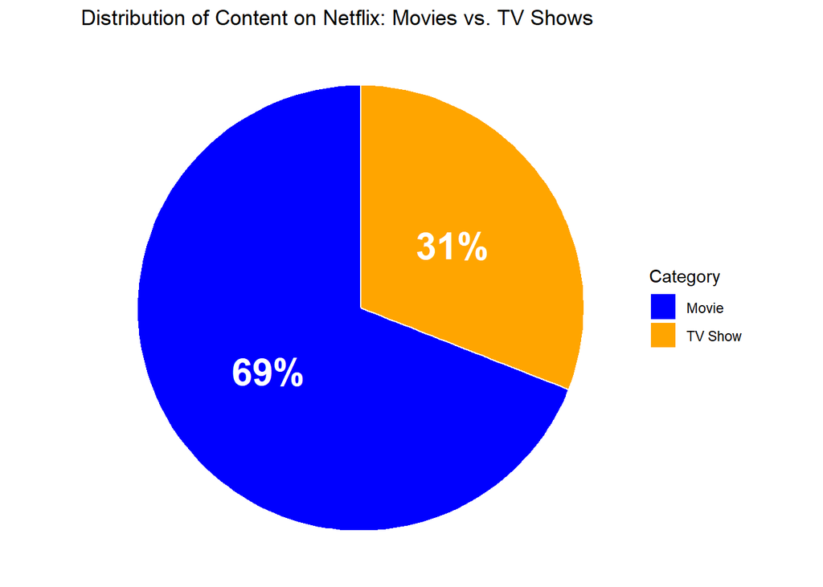

```r
count<-table(data_netflix$type) #this is to see how many are movies in your data and how many are TV shows.
count_df <-as.data.frame(count) #this converts the table to something that ggplot can use

# Renames the column
names(count_df) <-c("type","count")

# We may also show the percentages
count_df$percent <- count_df$count / sum(count_df$count) * 100

# Creating the pie chart
ggplot(count_df, aes(x = "", y = count, fill = type)) +
  geom_bar(width = 1, stat = "identity", color = "white") +
  geom_text(aes(label = paste0(round(percent), "%")),  # Here, we add the percentage labels using geom_text
            position = position_stack(vjust = 0.5),
            size = 8,
            fontface = "bold",
            color = "white") +
  coord_polar("y") +
  scale_fill_manual(values = c("blue", "orange")) +
  labs(title = "Distribution of Content on Netflix: Movies vs. TV Shows", x = NULL, y = NULL, fill = "Category") +
  theme_void()
```

We see here clearly that 69% (5377) of all the contents in Netflix are movies, while 31% (2410) are TV shows.

### 2. Provide descriptive statistics for TV and Movie based on the *duration*.

#### Descriptive Statistics for Movies

From *data_movie*, we observe that the data type for duration is character using (this can be confirmed using the `class()` function). We first transform this to *numeric* using `as.numeric()` function so that it could be used by ggplot.

```r
# Transforming duration to numeric variable
movieDuration_numeric <- as.numeric(gsub(" min", "", data_movie$duration)) # notice here that we also removed 'min' (or replaced with "(empty)") using gsub() function
```

```r
# Descriptive Statistics
describe(movieDuration_numeric)
```

```
   vars    n  mean    sd median trimmed   mad min max range skew kurtosis   se
X1    1 5377 99.31 28.53     98    99.3 20.76   3 312   309 0.19     2.04 0.39
```

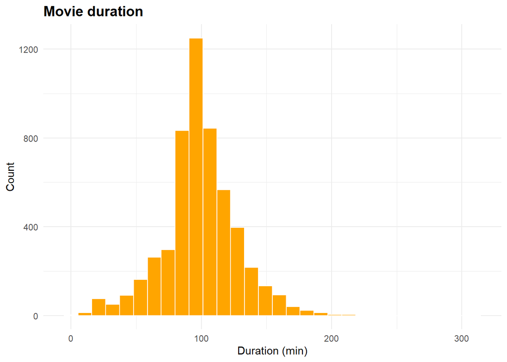

```r
# Creating the histogram
ggplot(data = data_movie, aes(x = movieDuration_numeric)) +
  geom_histogram(color = "white", fill = "orange") + # number of bins will be decided by R
  theme_minimal()+
  labs(
    title = "Movie duration",
    x = "Duration (min)",
    y ="Count",
  )+
  theme(
    plot.title = element_text(color = "black", size = 14, face = "bold"),
  )
```

We see from the histogram that most of the movies have a duration of around 100 minutes. While not exactly seen from the histogram, there are extreme outliers; longest duration is 312 minutes, while shortest is 3 minutes as seen in the descriptive statistics above. The histogram also highly resembles a bell curve.

#### Descriptive Statistics for TV Shows

For the case of TV shows, we have to also convert it to numeric and remove the word ‘season’ and ‘seasons’. We will use the same functions as the ones in Movies.

```r
# Transforming duration to numeric variable
tvDuration_numeric <- as.numeric(gsub(" Season(s)?", "", data_tv$duration))
```

```r
# Descriptive Statistics
describe(tvDuration_numeric)
```

```
   vars    n mean  sd median trimmed mad min max range skew kurtosis   se
X1    1 2410 1.78 1.6      1    1.38   0   1  16    15 3.36    15.32 0.03
```

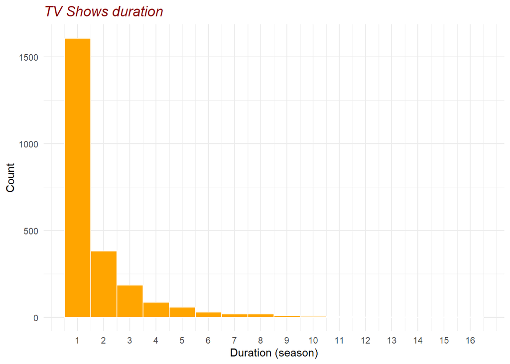

```r
# Creating the histogram
ggplot(data = data_tv, aes(x = tvDuration_numeric)) +
  # Since there are relatively few numbers of unique duration, we will use that as the number of bins.
  geom_histogram(bins = 16, color = "white", fill = "orange") +
  theme_minimal()+
  labs(
    title = "TV Shows duration",
    x = "Duration (season)",
    y ="Count",
  )+
  theme(
    plot.title = element_text(color = "darkred", size = 14, face = "italic"),
  )+
  scale_x_continuous(breaks = 1:16)  # Set x-axis labels from 1 to   16
```

We notice here that most of the TV Shows have one season. There is a very noticeable outlier; a TV show that have 16 seasons. We also notice that the histogram seems to resemble a logarithmic decay.

#### Summary Table

For this part, in-line code was used.

|  | Movie | TV Show |
| --- | --- | --- |
| **Total** | 5377 | 2410 |
| **Missing** | 0 | 0 |
| **Valid** | 5377 | 2410 |
| **Mean** | 99.3079784 minutes | 1.7759336 Seasons |
| **Standard Deviation** | 28.5308808 | 1.596359 |

### 3. TV Shows and Movies before and after I was born . . .

#### For Movies

```r
birth_year = 2002

## This creates a new categorical variable 'release_byear' in the data_movie dataset
birthYear_data_movie <- data_movie %>%
  mutate(
    release_byear = case_when(
      release_year < birth_year ~ "Before 2002",
      release_year == birth_year ~ "Same (2002)",
      release_year > birth_year ~ "After 2002"
    )
  )
# We will use the 'count' function from dplyr to show the count of 'after', 'before', 'same'
count_releaseByear <- birthYear_data_movie %>%
  count(release_byear)

print(count_releaseByear)
```

```
# A tibble: 3 × 2
  release_byear     n
  <chr>         <int>
1 After 2002     4874
2 Before 2002     464
3 Same (2002)      39
```

There are 4874 movies released after I was born, 464 before, and 39 on the same year I was born.

#### For TV Shows

```r
## Similarly, we do this for 'TV Show' type, data_tv
birthYear_data_tv <- data_tv %>%
  mutate(
    release_byear = case_when(
      release_year < birth_year ~ "Before 2002",
      release_year == birth_year ~ "Same (2002)",
      release_year > birth_year ~ "After 2002"
    )
  )
count_releaseByear <- birthYear_data_tv %>%
  count(release_byear)

print(count_releaseByear)
```

```
# A tibble: 3 × 2
  release_byear     n
  <chr>         <int>
1 After 2002     2349
2 Before 2002      55
3 Same (2002)       6
```

There are 2349 TV Shows released after I was born, 55 before, and 6 on the same year I was born.

### 4. Saving the modified datasets and clearing the memory

```r
# Saving the modified datasets
save(birthYear_data_movie, file = "birthYear_data_movie.RData")
save(birthYear_data_tv, file = "birthYear_data_tv.RData")

rm(list=ls()) #Since we do not need any of the datasets above, we will clear everything
```

# **The Probability Pilgrims: A Journey Through Monte Carlo**

### 1. OLS Regression

#### a. Generating sample data

Q: Generate an independent variable that is n=1350, with values from 0 to 100 and a dependent variable that is 2 time of the independent variable with random value drawn from a normal distribution with a mean of 0 and a standard deviation of 2.

```r
# We may set seed for replicablity
set.seed(9823)

# Independent variable (x)
n <- 1350
x<-runif(n, 0, 100)

# Dependent variable (y)
y <- 2*x + rnorm(n, 0, sd = 2)
```

#### b. Running the regression

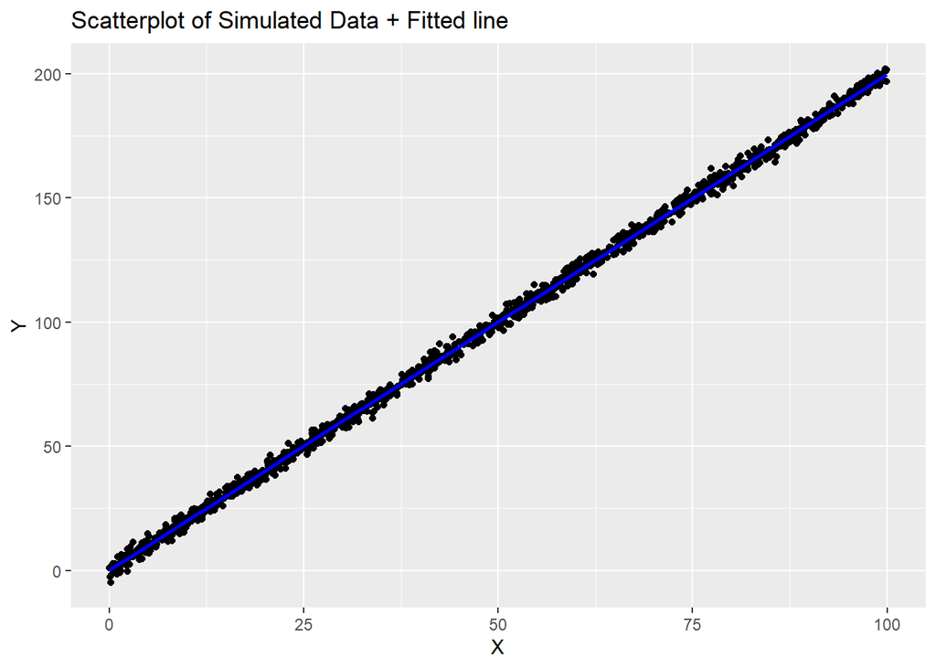

```r
ggplot(data = data.frame(x, y), aes(x = x, y = y)) +
  geom_point() +
  geom_smooth(method = "lm", se = FALSE, color = "blue") +
  labs(title = "Scatterplot of Simulated Data + Fitted line",
       x = "X", y = "Y")
```

```r
model0 <- lm(y ~ x)

## printing the results:

# Coeffecients
cat("Intercept (β₀): ", coef(model0)[1], "\n")
```

```
Intercept (β₀):  0.09468007
```

```r
cat("Coefficient for X (β₁): ", coef(model0)[2], "\n")
```

```
Coefficient for X (β₁):  1.997997
```

```r
# Adjusted R-squared
cat("Adjusted R-squared: ", summary(model0)$adj.r.squared, "\n")
```

```
Adjusted R-squared:  0.998755
```

```r
# F-statistic and p-value
cat("F-statistic:", summary(model0)$fstatistic[1], "\n")
```

```
F-statistic: 1082214
```

```r
p_val = pf(summary(model0)$fstatistic[1],summary(model0)$fstatistic[2],summary(model0)$fstatistic[3],lower.tail=FALSE)
cat("p-value:", p_val, "\n")
```

```
p-value: 0
```

#### b.1 Interpretation

The null hypothesis is: the indepdent variable x has no effect on the dependent variable y.

Since the p-value approaches 0, i.e., p-value<0.05, and F-statistics is very large, we reject the null hypothesis. Therefore, there is significant evidence that the variable x affects variable y.

And, since the coefficient is +1.997, this means that that there is a direct relationship between x and y (as x increases, y increases).

The Adjusted R-squared (0.998755) is very close to 1.00, this implies that our fitted line is a very good fit.

#### c. Replications and Descriptive Statistics

```r
set.seed(9823) # we set seed for replicability

## Replication function
sim2<-function(n){
  x<-runif(n, min=0, max=100)
  y <- 2*x + rnorm(n, 0, 2)
  ols<-lm(y~x, data=data.frame(y,x))
  b<-ols$coefficients
  return(b)
}

# for 1000 replications and n = 300,
rep_mc <- replicate(1000, sim2(n=300))

# -------------------------------------

## Results

# Descriptive statistics for intercepts (b0)
intercepts <- rep_mc[1,]
mean_intercept <- mean(intercepts)
sd_intercept <- sd(intercepts)
min_intercept <- min(intercepts)
max_intercept <- max(intercepts)
quantiles_intercept <- quantile(intercepts)

# Descriptive statistics for slopes (b1)
slopes <- rep_mc[2,]
mean_slope <- mean(slopes)
sd_slope <- sd(slopes)
min_slope <- min(slopes)
max_slope <- max(slopes)
quantiles_slope <- quantile(slopes)

# -------------------------------------

## Displaying the results

cat("Intercepts:\n")
```

```
Intercepts:
```

```r
cat("Mean:", mean_intercept, "\nSD:", sd_intercept, "\nMin:", min_intercept, "\nMax:", max_intercept, "\n")
```

```
Mean: -0.004681945
SD: 0.2307298
Min: -0.7830602
Max: 0.6461252
```

```r
cat("Quantiles:", quantiles_intercept, "\n\n")
```

```
Quantiles: -0.7830602 -0.1656264 -0.0007589925 0.1588191 0.6461252
```

```r
cat("Slopes:\n")
```

```
Slopes:
```

```r
cat("Mean:", mean_slope, "\nSD:", sd_slope, "\nMin:", min_slope, "\nMax:", max_slope, "\n")
```

```
Mean: 2.000058
SD: 0.004071423
Min: 1.986641
Max: 2.012294
```

```r
cat("Quantiles:", quantiles_slope, "\n")
```

```
Quantiles: 1.986641 1.997427 2.000098 2.00276 2.012294
```

For 1000 replications and 300 observations, we see that the standard deviation for both intercepts and slopes are low, which means that there is little variability among different replications.

# Slope Seekers: The Quest for Linear Regression

```r
data(beauty)
```

## Bivariate Regression

### 1. Choosing the dependent and independent variables

*lwage* was chosen instead of *wage*. When looking at the histogram of *wage*, there are extreme outliers that skewed the distribution to the right (while not being asked, the histogram of wage is provided below for reference). Taking the logarithm transform of wage helps to normalize the distribution which is generally more desirable for statistical analysis.

With this, our null hypotheses are:

- Null: Union membership does not affect the log(wage) of employees
- Alternative: Union membership affects the log(wage) of employees.

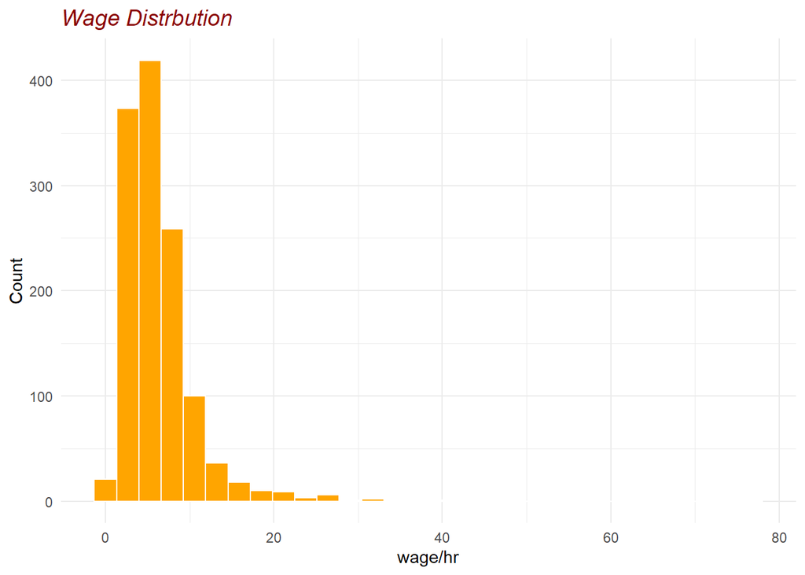

```r
ggplot(data = beauty, aes(x = wage)) +
  geom_histogram(color = "white", fill = "orange") +
  theme_minimal()+
  labs(
    title = "Wage Distrbution",
    x = "wage/hr",
    y ="Count",
  )+
  theme(
    plot.title = element_text(color = "darkred", size = 14, face = "italic"),
  )
```

### 2. Descriptive Statistics

#### Descriptive Statistics and Histogram for *lwage*

```r
describe(beauty$lwage)
```

```
   vars    n mean   sd median trimmed  mad  min  max range skew kurtosis   se
X1    1 1260 1.66 0.59   1.67    1.66 0.55 0.02 4.35  4.33 0.08     0.42 0.02
```

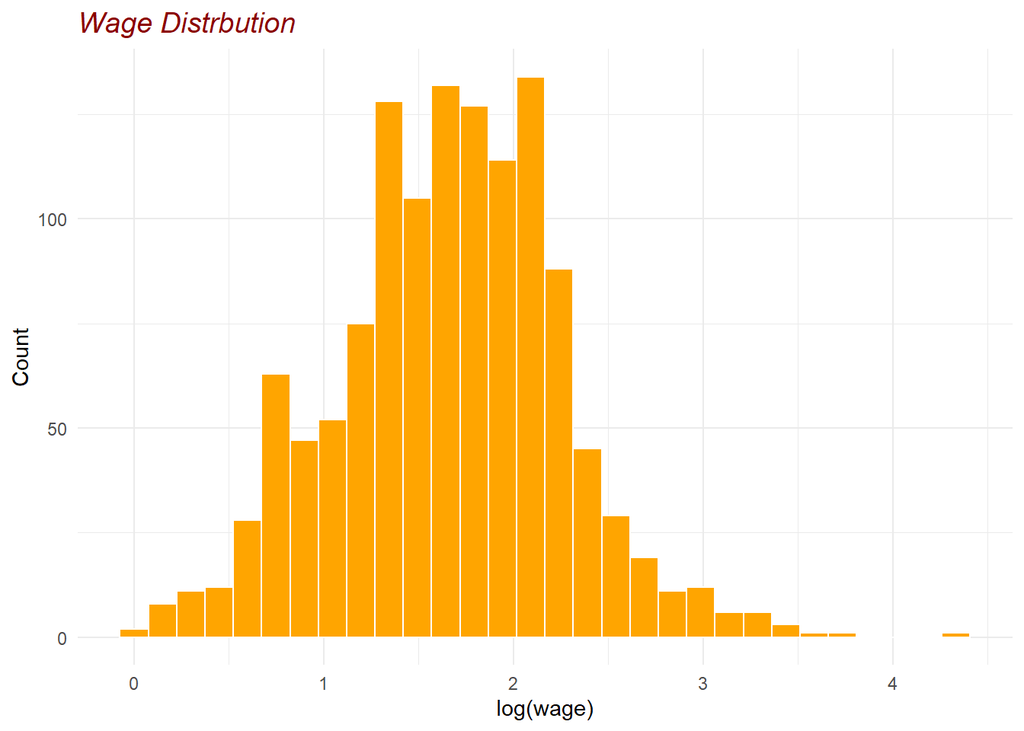

```r
ggplot(data = beauty, aes(x = lwage)) +
  geom_histogram(color = "white", fill = "orange") +
  theme_minimal()+
  labs(
    title = "Wage Distrbution",
    x = "log(wage)",
    y ="Count",
  )+
  theme(
    plot.title = element_text(color = "darkred", size = 14, face = "italic"),
  )
```

#### Descriptive Statistics and Histogram for *union*

```r
describe(beauty$union)
```

```
   vars    n mean   sd median trimmed mad min max range skew kurtosis   se
X1    1 1260 0.27 0.45      0    0.22   0   0   1     1 1.02    -0.96 0.01
```

We know that the variable *union* is a categorical variable (binary). This means that the interpretation for this descriptive statics is different. For instance, the mean represents the percentage of the people that are a union member (27%) since the sum of the observation is just the number of ‘1s’ in the observations. The standard deviation does not provide us any meaningful interpretation about the spread of the data since there are only two possible values. This is also the case for the median, min, max, etc.

In the original dataset, the datatype of the variable *union* is an integer [we used here `class(beauty$union)` to check]. We may change this to categorical (dummy) variable using the `factor()` function:

```r
# Here, we created a different variable union_cat to hold the categorical variable for union
beauty$union_cat <- factor(beauty$union)
```

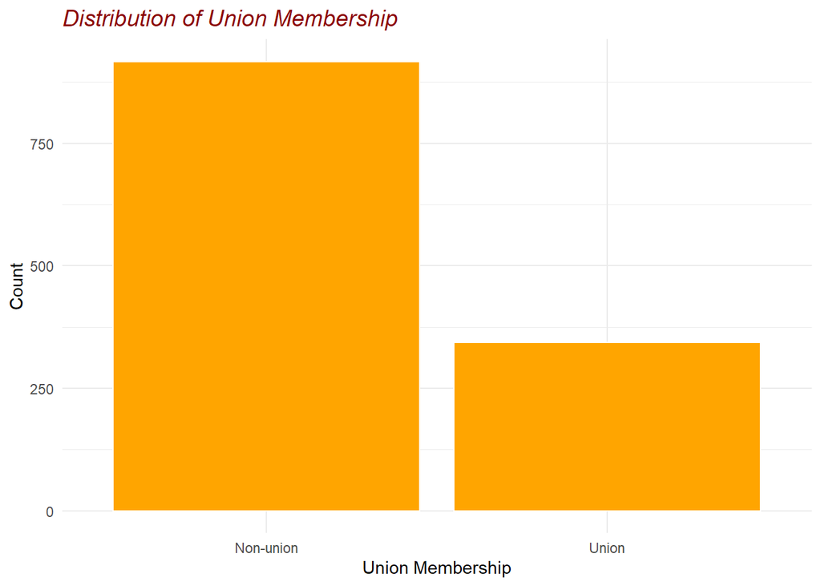

```r
## Since union is a categorical variable, we may use geom_bar instead
ggplot(data = beauty, aes(x = union_cat)) +   # we used union_cat instead of union
  geom_bar(color = "white", fill = "orange") +
  scale_x_discrete(labels = c("Non-union", "Union")) +
  theme_minimal() +
  labs(
    title = "Distribution of Union Membership",
    x = "Union Membership",
    y = "Count"
  ) +
  theme(
    plot.title = element_text(color = "darkred", size = 14, face = "italic")
  )
```

We see from this histogram there there are 920 that are not part of any union (73%) and 340 who are part of a union (27%).

### 3. Run the regression and interpret the results

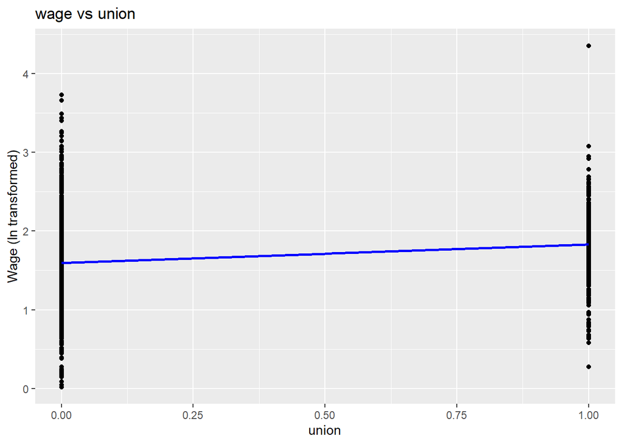

```r
ggplot(data = beauty, aes(x = union, y = lwage)) +
  geom_point() +
  geom_smooth(method = "lm", se = FALSE, color = "blue") +
  labs(title = "wage vs union",
       x = "union", y = "Wage (ln transformed)")
```

From the plot, we see that there may be a positive relationship between union membership and wage. We will confirm that using the `summary()` function below.

```r
# Notice here union was used instead of union_cat
# In R, I noticed that when we use a categorical variable in a linear regression model, R automatically treats it as a factor variable, even if the original variable is of integer type. Hence, it does not matter whether we use union or union_cat.
model <- lm(lwage ~ union, data = beauty)
summary(model)
```

```
Call:
lm(formula = lwage ~ union, data = beauty)

Residuals:
     Min       1Q   Median       3Q      Max
-1.57464 -0.36763  0.00495  0.35105  2.52225

Coefficients:
            Estimate Std. Error t value Pr(>|t|)
(Intercept)  1.59444    0.01933  82.486  < 2e-16 ***
union        0.23642    0.03705   6.381 2.46e-10 ***
---
Signif. codes:  0 '***' 0.001 '**' 0.01 '*' 0.05 '.' 0.1 ' ' 1

Residual standard error: 0.5853 on 1258 degrees of freedom
Multiple R-squared:  0.03136,   Adjusted R-squared:  0.03059
F-statistic: 40.72 on 1 and 1258 DF,  p-value: 2.462e-10
```

Furthermore, with the pvalue (2.462e-10) being clearly less than 0.05, we reject the null hypothesis. This means that the there is enough evidence to say that union membership increases the percentage wage of employees. We can also see that the 3-asterisk (***) means that coefficient of *union* is ‘highly significant’ at the 0.001 level.

### 4. Run assumption diagnostics and interpret

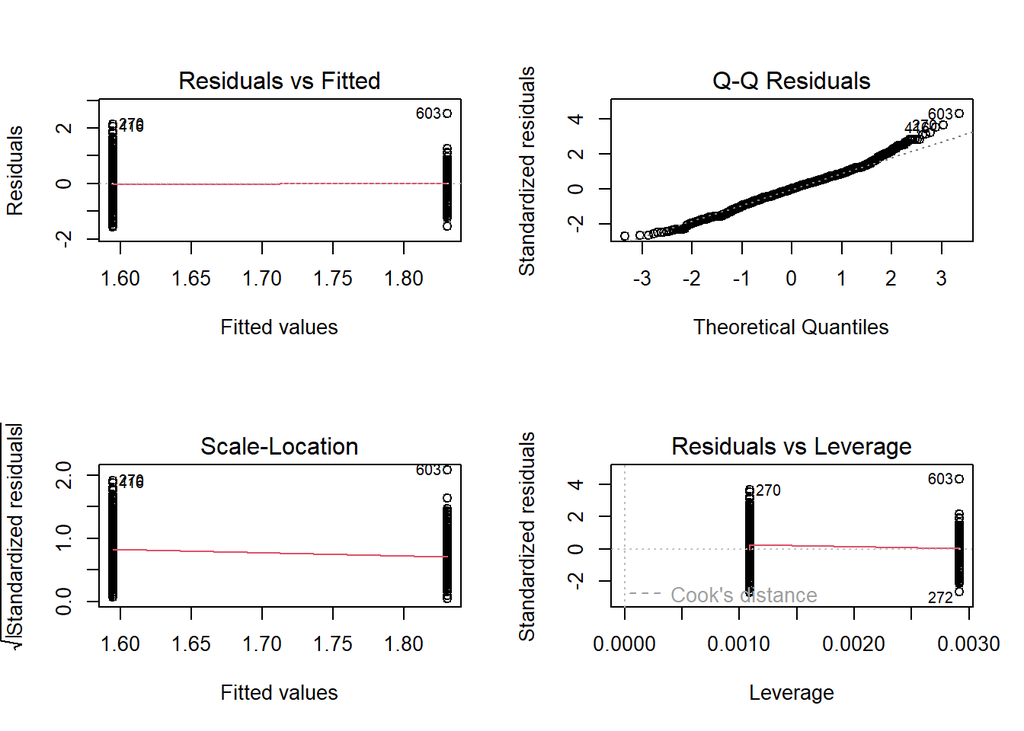

```r
par(mfrow = c(2, 2))
plot(model)
```

In the Q-Q residuals, we can see that there is a deviation (bent upwards) in the straight line. This indicates a indicate skewness and heavy-tailed residuals.

In the residuals vs leverage plot, we cannot extract any meaningful insights here since the residuals are only concentrated into two values in the x-axis. Hence, we cannot pinpoint what values are ‘influential’.

Since there are violations of the assumptions in the OLS model, our previous interpretation may be unreliable.

## Multivariate Regression

### 1. Choose what additional independent variables you will add; it is suggested that independent variables be less than 4. Explain why you chose those variables to be added.

I chose to add the variables *female* and *bigcity*. Women in the workplace has always been undervalued and paid less throughout history. It is interesting to see if this notion holds in this dataset. On the other hand, people living in the big cities tend to be paid more since the cost of living in big cities are higher. It would be interesting as well to investigate this using this dataset.

The additional hypotheses are therefore:

For *female*

- Null: Being female has no significant effect on log(wage)
- Alternative: Being female has significant effect on log(wage)

For *bigcity*

- Null: Living in a big city has no significant effect on log(wage)
- Alternative: Living in big city has significant effect on log(wage)

### 2. Descriptive Statistics on the additional variables

```r
describe(beauty$female)
```

```
   vars    n mean   sd median trimmed mad min max range skew kurtosis   se
X1    1 1260 0.35 0.48      0    0.31   0   0   1     1 0.65    -1.58 0.01
```

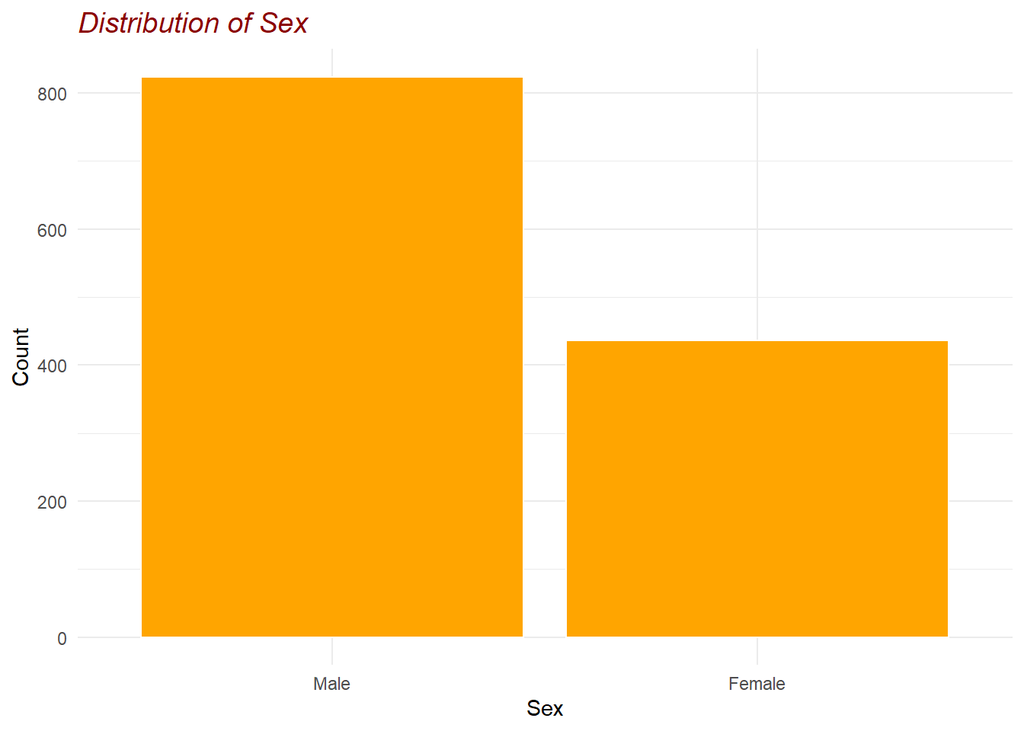

```r
# Here, we created a different variable female_cat to hold the categorical variable for female
beauty$female_cat <- factor(beauty$female)

## Since union is a categorical variable, we may use geom_bar instead
ggplot(data = beauty, aes(x = female_cat)) +   # we used female_cat instead of female
  geom_bar(color = "white", fill = "orange") +
  scale_x_discrete(labels = c("Male", "Female")) +
  theme_minimal() +
  labs(
    title = "Distribution of Sex",
    x = "Sex",
    y = "Count"
  ) +
  theme(
    plot.title = element_text(color = "darkred", size = 14, face = "italic")
  )
```

```r
describe(beauty$bigcity)
```

```
   vars    n mean   sd median trimmed mad min max range skew kurtosis   se
X1    1 1260 0.22 0.41      0    0.15   0   0   1     1 1.36    -0.16 0.01
```

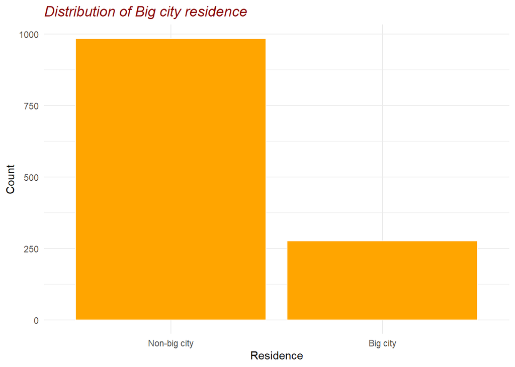

```r
# Here, we created a different variable female_cat to hold the categorical variable for female
beauty$bigcity_cat <- factor(beauty$bigcity)

## Since union is a categorical variable, we may use geom_bar instead
ggplot(data = beauty, aes(x = bigcity_cat)) +   # we used bigcity_cat instead of bigcity
  geom_bar(color = "white", fill = "orange") +
  scale_x_discrete(labels = c("Non-big city", "Big city")) +
  theme_minimal() +
  labs(
    title = "Distribution of Big city residence",
    x = "Residence",
    y = "Count"
  ) +
  theme(
    plot.title = element_text(color = "darkred", size = 14, face = "italic")
  )
```

```r
model_multi <- lm(lwage ~ union + female + bigcity, data = beauty)
summary(model_multi)
```

```
Call:
lm(formula = lwage ~ union + female + bigcity, data = beauty)

Residuals:
    Min      1Q  Median      3Q     Max
-1.6938 -0.3497 -0.0028  0.3177  2.7274

Coefficients:
            Estimate Std. Error t value Pr(>|t|)
(Intercept)  1.74260    0.02193  79.445  < 2e-16 ***
union        0.16148    0.03314   4.873 1.24e-06 ***
female      -0.52589    0.03091 -17.012  < 2e-16 ***
bigcity      0.24752    0.03549   6.974 4.98e-12 ***
---
Signif. codes:  0 '***' 0.001 '**' 0.01 '*' 0.05 '.' 0.1 ' ' 1

Residual standard error: 0.5193 on 1256 degrees of freedom
Multiple R-squared:  0.2389,    Adjusted R-squared:  0.2371
F-statistic: 131.4 on 3 and 1256 DF,  p-value: < 2.2e-16
```

The p-values for *union*, *female,* and *bigcity* are all less than 0.05 and are all highly significant at 0.001. This means that we reject all the null hypotheses. Therefore, there is enough evidence to say that:

- Union membership has significant effect on log(wage)
- Being female has significant effect on log(wage)
- Living in big city has significant effect on log(wage)

### 4. I want you to compare the goodness of fit (Adjusted R-squared, p-value and F-statistics) with your bivariate regression. Is there an improvement?

|  | Bivariate | Multivariate |
| --- | --- | --- |
| **Adjusted R-squared** | 0.03059 | 0.2371 |
| **p-value** | 2.462e-10 | 2.21e-16 |
| **F-statistics** | 40.72 | 131.4 |

From the table, we can see clearly that there is an improvement in the goodness of fit. R-squared is now higher, and F-statistics is higher, and the p-value is lower. This suggests that in the bivariate regression, adding the two independent variables allows the model to capture additional variation in the dependent variable that may not have been accounted for by the initial independent variable (*union*). Also, by incorporating additional independent variables, the model may have became better in explaining the variability in *lwage*, resulting in smaller residuals and a better fit to the data.

### 5. Perform Assumption Diagnostics. If you are not sure with the plots, use the tests you learned. You do not have to perform all, unless you are unsure about the four plots and the correlation matrix.

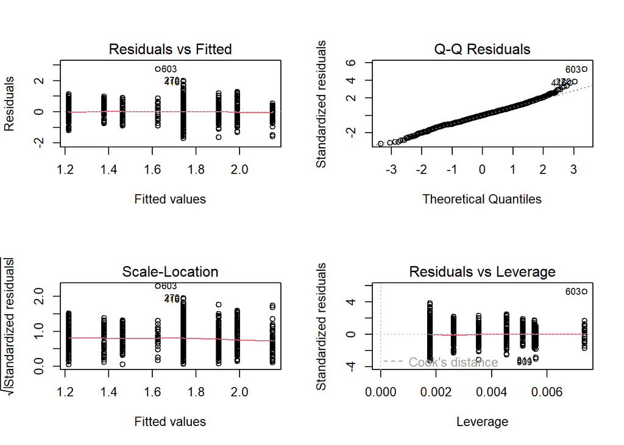

```r
par(mfrow = c(2, 2))
plot(model_multi)
```

Similar with the bivariate regression, we see here that the datapoints for Residuals vs Fitted, Scale-Location, and Residuals vs Leverage concentrate on only very few x-axis values. Clearly, we do not see the random scattering of datapoints around the horizontal line which should be ideal. Hence, this indicate violation of the linearity assumption (in residuals vs fitted) and homoscedasticity (in scale-location). Both of which are violation of the assumptions in OLS model.

In the Q-Q residuals, we can see that there is a deviation (bent upwards) in the straight line. This indicates a indicate skewness and heavy-tailed residuals.

In the residuals vs leverage plot, we cannot extract any meaningful insights since the residuals are only concentrated into few values in the x-axis. Hence, we cannot actually observe which values are considered ‘influential’.

**We may also use the tests:**

```r
# Using the White Test
whitestrap::white_test(model_multi)
```

```
White's test results

Null hypothesis: Homoskedasticity of the residuals
Alternative hypothesis: Heteroskedasticity of the residuals
Test Statistic: 6.25
P-value: 0.043958
```

While close to 0.05, p-value is still less than 0.05. Hence, we reject the null hypothesis. This means that there is heteroskedasticity of the residuals which is a violation of our assumption.

```r
# Using the studentized Breusch-Pagan test
lmtest::bptest(model_multi)
```

```
    studentized Breusch-Pagan test

data:  model_multi
BP = 11.037, df = 3, p-value = 0.01153
```

**Since there are violations in the assumptions, our previous interpretations may not be unreliable.**

# Data Stewards: Managing Metrics for Econometric Insights

All the parts of the problem set are essential in building the intuition behind using R and applying econometrics in the real world. The first problem regarding data rangers focuses on the basics of data management which is helpful especially in the pre-processing of data. Correctly and efficiently handling data are the first steps in making a reliable program. The technical skills I learned from this portion is not only limited to its application to R, but also in other programming languages where the same intuition commonly applies. Meanwhile, probability pilgrims mostly teach us about the basics of data generating process using R, as well as using R as a tool to run large-scale simulations that cannot normally be done manually. While the technical founadations behind data generating process and Monte Carlo Simulations are very complex (as discussed in ECOMETR), using R to do them made them way less intimidating. Through this part, I learned that the possibilities are seemingly limitless in simulating even large datasets (as long as the computer is capable of it, of course). The bivariate and multivariate regression parts are when we are actually exposed to the application of these statistical techniques to the real world. It is a very meaningful problem since we are able to interpret the relationships among real data using theories that are relatively hard to grasp when learned only using formal mathematics. Finally, the essay portion is a good finisher to collate our insights and synthesize our learning experiences from the problem set. It allows us to not only reflect on what we have done, but also to reflect on the technical skills we have acquired that will most likely be helpful in the future.